# Multi-ancestry placental xQTL analysis

Internal QC + R21 progress report

Bhattacharya Lab (analysis: S. Bresnahan; report generated with Biomni/Phylo)

2026-10-01

# 1 Executive summary

This report summarizes the multi-ancestry placental xQTL analysis: cohort-only genotype PCA on LD-pruned variants within each ancestry stratum, a conventional covariate set (first 5 genotype PCs + HCP factors + sex, gestational age, and cell-type fractions; maternal cell fraction excluded before correlation pruning at |r| > 0.9; HCP count optimized per ancestry × modality via module 25b; no covariate cap), a MAF ≥ 0.01 filter with a ≥ 5 minor-allele-count floor at the genotype intersection, Storey q-values (computed with the R `qvalue` package), and per-phenotype rank-based inverse-normal transformation of all modalities (isoform usage mapped as within-gene relative-abundance ratios; isoform expression as transcript-level TPM abundance). Mapping covers 36 ancestry × modality × layer cells (EAS n ≈ 280, EUR n ≈ 140). The results narrative follows the figure progression of the developing-brain xQTL atlas (Wen et al., Science 2024): cohort landscape → calibration → the modality-wise regulation landscape → cross-ancestry regulation → the discovery catalog → functional characterization.

**Headline result: 7328 phenotype-level associations reach FDR ≤ 5%** in the discovery layer (ungrouped scan for the 8 multi-phenotype modalities + the per-gene expression scan): 2707 in EAS and 4621 in EUR, implicating 1667 / 2470 unique genes respectively. This phenotype-level set is the input to cross-ancestry SuSHiE fine-mapping (Methods). At gene level, the combined cross-modality catalog contains **1311 EAS and 2184 EUR eGenes** at FDR ≤ 5%, with per-modality grouped eGenes as the breakdown. Strongest association per ancestry: EAS: ENSG00000290199 (expression, grouped layer, q = 2.1e-25); EUR: ERAP1 (alt_polyA, ungrouped layer, q = 1.8e-36). Storey calibration estimates a signal fraction (π1) of 6–44% across cells. In high-signal cells Storey q-values are correspondingly more liberal than Benjamini–Hochberg (by up to the estimated π0); the per-cell comparison is in Calibration.

The splicing modality splits by ancestry. At its modality-matched HCP count (HCP count optimization), EUR splicing yields 423 FDR ≤ 5% eGenes — under expression-derived covariates the layer carried no detectable signal, so the EUR splicing null was a covariate-specification artifact, now resolved. EAS splicing remains near-null in both the grouped (5 eGenes, best q = 0.0022) and ungrouped (5 phenotype-level hits) layers, its eGene yield is flat across the HCP grid, and its p-values depart only mildly from the null at the median (genomic-control λ = 1.27; Calibration). Three lines of evidence bear on the residual EAS null:

1. **The machinery detects splicing signal where it exists** — the same pipeline and covariate machinery yield the EUR splicing catalog above at n ≈ 140, a *higher* detection floor (r² ≈ 0.19) than EAS (r² ≈ 0.10 at n = 280; Power analysis). A pure sample-power explanation is therefore insufficient for EAS: EUR splicing effects cleared a higher bar. The leading candidate is EAS-specific attenuation of the splicing phenotypes — EAS pools four cohorts spanning single- and paired-end protocols, and junction-level quantification is the most protocol-sensitive of the nine modalities.
2. **The EAS null is not a covariate artifact** — eGene yield does not improve at any HCP count on the grid (HCP count optimization), and the mild median λ elevation with only a handful of FDR-significant hits is the signature of diffuse, individually weak effects rather than of residual confounding (which would inflate the median without bound) or of a dead layer (λ ≈ 1, no tail). The FDR-significant hits in the other modalities carry estimated r² of 0.00–0.77 — exactly the class of outsize effect the floor permits.
3. **Signal replicates across ancestries** — cross-ancestry rank concordance of gene-level signal on the combined layer is Spearman ρ = 0.16 (top-100 overlap 26/100), with same-variant slope concordance 0.63 — the pattern expected of real, partially shared genetic regulation, not of artifact-driven signal.

**Carrier-count caveat.** A fraction of tested pairs retain < 5 minor-allele carriers in the mapping sample sets (EAS: 0 tests; EUR: 43343 tests; audit table below) — the MAC ≥ 5 floor was applied before outlier exclusion. Flagged tests should be discounted; no FDR-significant result should be carrier-limited. # Methods

*Adapted from the project methods document (methods_placenta_xqtl.docx).*

## 1.1 Study cohorts and data

Placental RNA-seq and genotype data were assembled from four cohorts (Table 1). NIEHS_RICHS contributed placenta RNA-seq and array genotypes under dbGaP controlled access. GUSTO contributed placenta RNA-seq and array genotypes through the study investigators. SNUH contributed placenta RNA-seq and genotypes available under SRA BioProject PRJNA820329 (102 RNA-seq runs). NIGMS contributed placenta RNA-seq and whole-exome sequencing (WXS) under SRA BioProject PRJNA671171 (154 RNA-seq runs and 95 WXS runs); each NIGMS subject was sampled at two placental sites, and the replicate libraries were averaged per individual before mapping. All genotype and transcriptomic data were processed against the GRCh38 no-alt analysis set (GCA_000001405.15).

| Cohort | Data types | Access | Accession / route |
| --- | --- | --- | --- |
| NIEHS_RICHS | Placenta RNA-seq, array genotypes | Controlled access | dbGaP (accession to be added on publication) |
| GUSTO | Placenta RNA-seq, array genotypes | On request | GUSTO study investigators |
| SNUH | Placenta RNA-seq, genotypes | Public | SRA BioProject PRJNA820329 |
| NIGMS | Placenta RNA-seq (2 sampling sites per subject), WXS | Public | SRA BioProject PRJNA671171 |

Table 1. Study cohorts, data types, and access routes.

## 1.2 Genotype processing and imputation

Array genotypes were lifted over to GRCh38 where required. For NIGMS, WXS reads were retrieved from SRA, aligned to GRCh38 with BWA, processed to per-sample gVCFs with GATK, and jointly genotyped per chromosome. Each cohort was filtered before imputation to biallelic SNPs with per-variant missingness of at most 0.05, minor allele frequency (MAF) of at least 0.01, and Hardy-Weinberg equilibrium (HWE) test P above 1 x 10^-6, and variants were left-aligned and normalized against the reference genome with bcftools norm. Genotypes were imputed on either the TOPMed (NIGMS, NIEHS_RICHS) or SEAD (GUSTO, SNUH) imputation servers. Imputed variants with imputation Rsq of at least 0.4 were retained and converted to plink2 binary format (pgen).

## 1.3 Ancestry assignment and cross-cohort genotype pooling

Genetic ancestry was assigned within each cohort with PC-AiR as implemented in GENESIS, using kinship estimated with KING in SNPRelate and 1000 Genomes phase 3 samples as the unrelated reference set. Each sample was assigned to one of five continental ancestry strata (AFR, AMR, EAS, EUR, SAS). For each stratum, the Rsq-passing variants of each cohort were subset to the assigned samples, multiallelic sites were split per cohort so that imputed dosages were partitioned correctly, and cohort VCFs were merged across cohorts with bcftools merge and normalized against GRCh38. Pooled genotypes were filtered to MAF of at least 0.01, HWE P above 1 x 10^-6, and per-variant missingness of at most 0.05, and palindromic duplicate sites were removed. The resulting per-ancestry pgen files define the genotype identifier space used by all downstream steps.

## 1.4 RNA-seq processing

RNA-seq reads for SNUH and NIGMS were retrieved from SRA with prefetch and fasterq-dump; GUSTO and NIEHS_RICHS FASTQs were already local. Adapters and low-quality bases were trimmed with Trim Galore 0.6.10. Reads were aligned to GRCh38 with STAR 2.7.4a in basic two-pass mode. Transcript abundance was quantified with Salmon 1.10.2 against the HPLRv2 long-read placental transcriptome annotation using automatic library-type detection, selective alignment with validateMappings, and 20 bootstrap replicates per sample.

## 1.5 Transcriptomic phenotyping

Nine RNA modalities were quantified per sample with an in-house rewrite of the PANTRY phenotyping pipeline (github.com/PejLab/Pantry) adapted to the local compute cluster. Gene expression was taken as gene-level abundance aggregated from Salmon with tximport. Isoform expression was taken as transcript-level TPM after quantification uncertainty correction (see below). Isoform usage was computed as within-gene relative abundance ratios after correcting transcript counts for quantification uncertainty: edgeR catchSalmon was used to estimate per-transcript overdispersion from the Salmon bootstrap replicates, and counts were divided by the estimated overdispersion (Chen et al., Nucleic Acids Res 2023). Alternative transcription start site and alternative polyadenylation usage were quantified with txrevise: event annotations were constructed in two event groups, each split into upstream, contained, and downstream positional classes, and event abundance was quantified with Salmon against the six resulting transcript indices. Splice junction usage was quantified by extracting junctions from the STAR alignments with RegTools and clustering them with leafCutter (minimum 30 reads per cluster, minimum cluster ratio 0.001); intron usage ratios within clusters were carried as phenotypes. Intron retention was quantified with MAJIQ. RNA editing levels were computed at REDIportal sites (TABLE1_hg38_v3) from samtools mpileup output as the proportion of edited reads per site. RNA stability was approximated per gene as the ratio of exonic to intronic read counts from featureCounts. Because splice junctions and retained introns are defined by the observed data in each cohort, splicing and intron retention features were harmonized across cohorts by stable genomic coordinates before pooling. Phenotypes were exported as bgzipped, tabix-indexed BED files with gene-level phenotype groupings where applicable.

## 1.6 Cell-type deconvolution

Cell-type proportions were estimated from bulk gene expression with MuSiC, using a published placental single-cell RNA-seq reference (GSE182381). The estimated fractions were carried into the mapping covariates.

## 1.7 RNA to DNA sample linkage

RNA-seq sample identifiers were linked to genotype sample identifiers within each cohort using cohort-specific keys: SRA run-to-subject metadata for SNUH and NIGMS, and array subject identifiers for NIEHS_RICHS and GUSTO. The linkage table was checked for match rates, duplicates, and missing values before mapping.

## 1.8 Phenotype pooling, normalization, and batch correction

Within each ancestry stratum, per-cohort phenotype matrices were pooled and normalized in a single pass, following the conventions of the developing-brain xQTL atlas (Wen et al., Science 2024). Gene and isoform expression were filtered to features with TPM above 0.1 in more than 25% of samples, and ratio-based modalities were filtered to features detected in at least 40% of samples. Filtered matrices were quantile normalized, and each phenotype was rank inverse-normal transformed. For expression, sample outliers were removed before batch correction using signed bicor network connectivity (z below -3). Cross-cohort batch effects were adjusted with ComBat (sva) with cohort as the batch variable, applied as the final normalization step.

## 1.9 Genotype principal components and sample quality control

Within each stratum, pooled genotypes were LD-pruned (plink2 indep-pairwise 200 50 0.2) and 20 principal components (PCs) were computed exactly; the first five PCs were retained as covariates. Genotype and phenotype sample sets were intersected on the linkage map, and variants were further required to have a minor allele count of at least 5 in the intersected samples. Samples more than 6 standard deviations from the mean on any of the first five genotype PCs were excluded.

## 1.10 Covariate assembly and hidden factor estimation

Mapping covariates comprised the first five genotype PCs, sex, gestational age, estimated cell-type fractions (with the dominant cell type as the compositional reference and the maternal fraction excluded), and hidden confounding factors estimated from batch-corrected expression with Rhcpp, using Picard alignment quality-control metrics as known covariates. Covariates with near-zero variance were dropped, and the remaining set was pruned iteratively at pairwise absolute correlation above 0.9, with retention priority given to sex and gestational age, then genotype PCs, then cell types, then hidden factors. The number of hidden factors was optimized separately for each ancestry and modality: factors were re-estimated at each k in {0…5…100} by 5, chromosome 1 was mapped with tensorQTL under each candidate covariate set (the full genome was mapped for modalities with fewer than 300 chromosome-1 phenotypes), and the k yielding the most eGenes at Storey q of at most 0.05 was selected, with ties resolved to the smaller k.

## 1.11 cis-xQTL mapping

cis-QTL mapping was performed per ancestry stratum and modality with tensorQTL 1.0.10 under GTEx conventions: a cis window of 1 Mb on either side of the phenotype start, MAF of at least 0.01, nominal and permutation passes, and Storey q-values computed on the permutation beta-approximated P values with the R qvalue package. For modalities with gene-level phenotype groupings, grouped permutation (group_s) was used to select one lead variant per gene; the remaining modalities were mapped ungrouped. Multiple independent signals per gene (grouped layers) or per phenotype (ungrouped layer) were identified with the stepwise conditional mode (map_independent). Three result layers were produced per ancestry: grouped, ungrouped, and a combined cross-modality layer in which phenotype identifiers are namespaced by modality.

## 1.12 Cross-ancestry fine-mapping

FDR-significant lead phenotypes (q of at most 0.05) were pooled across ancestries per modality — from the primary per-gene scan for expression and from the ungrouped phenotype-level scan for all other modalities — and each locus was fine-mapped jointly across ancestries with SuSHiE (version 0.20 or later) in individual-level mode, using in-sample linkage disequilibrium from the intersected genotypes and the exact tested cis windows. The number of effects per locus was set to min(10, max(5, n_independent + 2)), where n_independent is the number of stepwise-conditional signals at the locus, and credible sets were filtered at a purity threshold of 0.5. Per-variant posterior inclusion probabilities (PIPs), credible-set membership, per-ancestry effect weights, and the cross-ancestry effect-size correlation were recorded for each locus.

## 1.13 Functional enrichment of fine-mapped variants

High-confidence variants (PIP of at least 0.9) were compared against all fine-mapped variants for enrichment in functional annotations. Variant consequences were annotated with fastVEP (GRCh38) and grouped into splice, loss-of-function, missense, synonymous, UTR, intron, regulatory, flanking, and intergenic classes. Regulatory annotations comprised ENCODE SCREEN candidate cis-regulatory element classes and placenta open-chromatin regions. Enrichment was tested with Fisher exact tests as the primary analysis, logistic regression adjusting for log10 distance to the transcription start site as a sensitivity analysis, and PIP-weighted enrichment; Benjamini-Hochberg FDR was applied within each test family.

## 1.14 Report-integration targeted lookups

To support cross-ancestry and cross-modality report panels without shipping genome-wide summary statistics, targeted association lookups were performed (script 35): for each FDR-significant lead (variant, phenotype) pair, the same pair’s slope, standard error, and nominal P value were recomputed in the other ancestry stratum and, for grouped-layer leads, across the gene’s phenotypes in every other modality within the same ancestry, by ordinary least squares on covariate-residualized genotypes and phenotypes. All unique lead variants were annotated with fastVEP consequence classes and intersected with ENCODE cCRE classes and placenta open-chromatin regions, and per-gene loss-of-function constraint metrics (pLI, LOEUF) were taken from gnomAD v2.1.1. Regional association scans (plus-minus 1 Mb) with linkage disequilibrium (r^2) to the lead variant were computed for two showcase loci (ERAP2 and the top shared non-expression-driver locus).

## 1.15 Software and computing

All pipeline stages were run on the MD Anderson seadragon high-performance computing cluster (LSF scheduler, RHEL8). Analyses used R 4.3.1 (GENESIS, GWASTools, SNPRelate, sva, Rhcpp, edgeR, tximport, rtracklayer, MuSiC, qvalue, data.table) and Python 3 (tensorqtl 1.0.10, sushie, pandas, pyarrow, genotypeio). The complete analysis codebase, including per-stage scripts, configuration files, and a step-by-step manifest, is available at github.com/sbresnahan/Placenta_xQTL_atlas.

# 2 Cohort and data landscape

*Cohort compilation and sample QC, in the style of DevBrain Fig. S1 (dataset compilation) and Fig. 2A (genotype PCA).*

## 2.1 Sample attrition

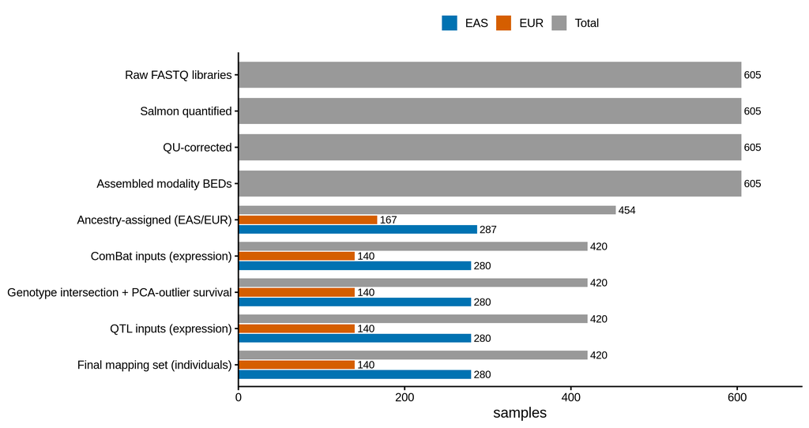

Sample attrition from raw FASTQ libraries to the final mapping sets. Pre-ancestry stages are cohort-wide run counts; post-ancestry stages count individuals (technical replicates share one array_id column).

| stage | EAS | EUR | Total |
| --- | --- | --- | --- |
| Raw FASTQ libraries | NA | NA | 605 |
| Salmon quantified | NA | NA | 605 |
| QU-corrected | NA | NA | 605 |
| Assembled modality BEDs | NA | NA | 605 |
| Ancestry-assigned (EAS/EUR) | 287 | 167 | 454 |
| ComBat inputs (expression) | 280 | 140 | 420 |
| Genotype intersection + PCA-outlier survival | 280 | 140 | 420 |
| QTL inputs (expression) | 280 | 140 | 420 |
| Final mapping set (individuals) | 280 | 140 | 420 |

Per-modality retention at the ComBat and QTL-input stages, in individuals (unique array_id; run-level counts are in attrition_summary.tsv).

| modality | ComBat | QTL input | ComBat | QTL input |
| --- | --- | --- | --- | --- |
| alt_polyA | 283 | 280 | 145 | 140 |
| alt_TSS | 283 | 280 | 145 | 140 |
| expression | 280 | 280 | 140 | 140 |
| intron_retention | 283 | 280 | 145 | 140 |
| isoform_expression | 283 | 280 | 145 | 140 |
| isoforms | 283 | 280 | 145 | 140 |
| RNA_editing | 283 | 280 | 145 | 140 |
| splicing | 282 | 279 | 143 | 138 |
| stability | 283 | 280 | 145 | 140 |

Two stage-specific notes. (1) ComBat runs upstream of the genotype intersection on one run per individual, so ComBat-stage membership (283 EAS / 145 EUR for the non-expression modalities; the expression ComBat BEDs were no longer present at archive time and are carried forward from the genotype-intersection stage) counts a single run per individual, whereas QTL-input membership (284 EAS / 161 EUR) flags every QC-passing run whose individual survives to mapping — both runs of a technical-replicate pair map to the same individual (array_id) column. Run-level counts can therefore exceed ComBat-stage counts without any sample gain; phenotype values for replicated individuals come from the single ComBat-processed run, run-level covariates are averaged across the pair, and the operative mapping sets are the per-individual counts. (2) Splicing is the only modality with QTL-input attrition (283 EAS / 158 EUR), from junction-level harmonization.

## 2.2 Cohort composition and genotype processing

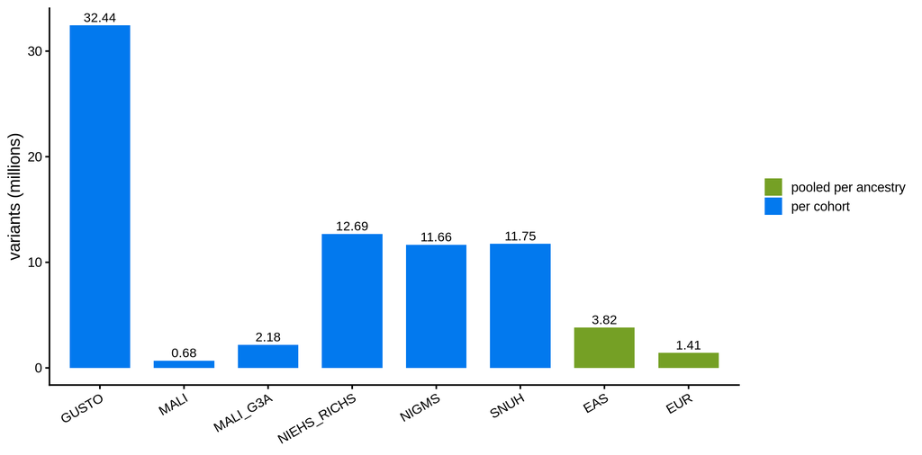

Variant and sample counts across genotype processing stages (line counts of the stage pvar/psam files; extraction script 35).

| entity | level | stage | n_variants | n_samples |
| --- | --- | --- | --- | --- |
| GUSTO | cohort | post-imputation (Rsq >= 0.4) | 32438826 | 1073 |
| MALI | cohort | post-imputation (Rsq >= 0.4) | 679175 | 746 |
| MALI_G3A | cohort | post-imputation (Rsq >= 0.4) | 2183144 | 746 |
| NIEHS_RICHS | cohort | post-imputation (Rsq >= 0.4) | 12685458 | 149 |
| NIGMS | cohort | post-imputation (Rsq >= 0.4) | 11655358 | 59 |
| SNUH | cohort | post-imputation (Rsq >= 0.4) | 11746974 | 102 |
| EAS | ancestry | pooled per-ancestry QC | 3819786 | 283 |
| EUR | ancestry | pooled per-ancestry QC | 1413586 | 146 |

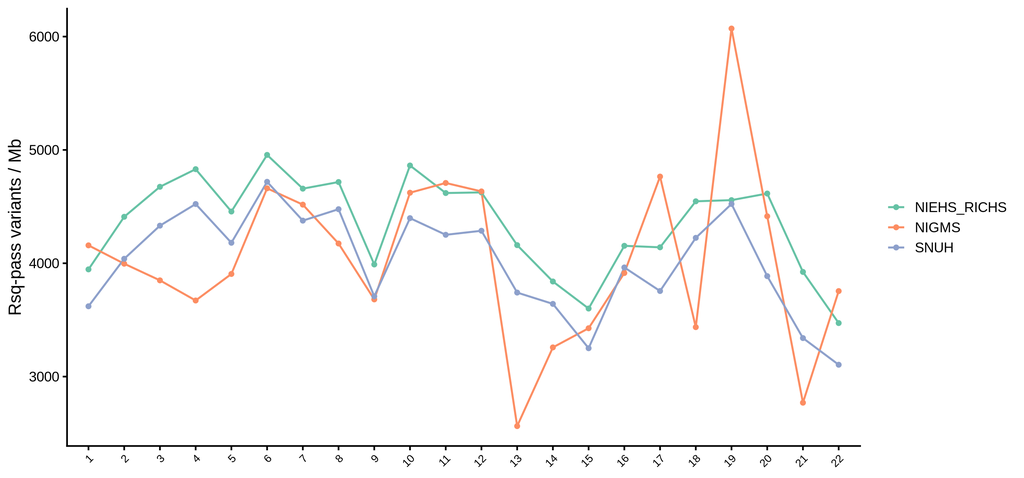

## 2.3 Genotype PCA

DevBrain Fig. 2A analog. Two views: (i) the PC-AiR coordinates computed against the 1000 Genomes reference during ancestry assignment (module 01_genotype_imputation; shared axes across cohorts), shown when the staged PC-AiR table is present in the archive; (ii) each stratum’s cohort-only PCA (LD-pruned variants; Methods) — **within-stratum** coordinates, faceted with free scales.

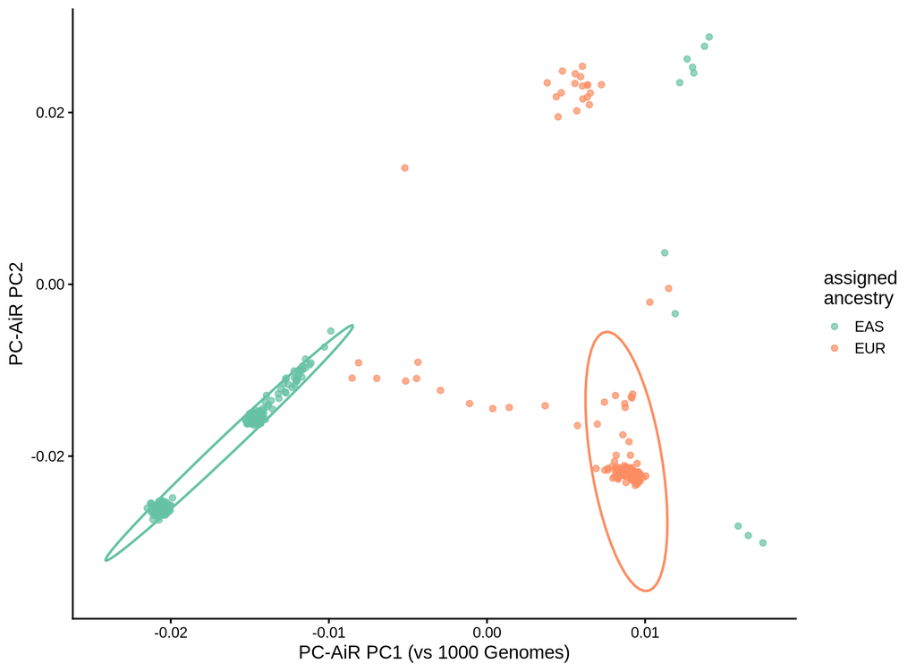

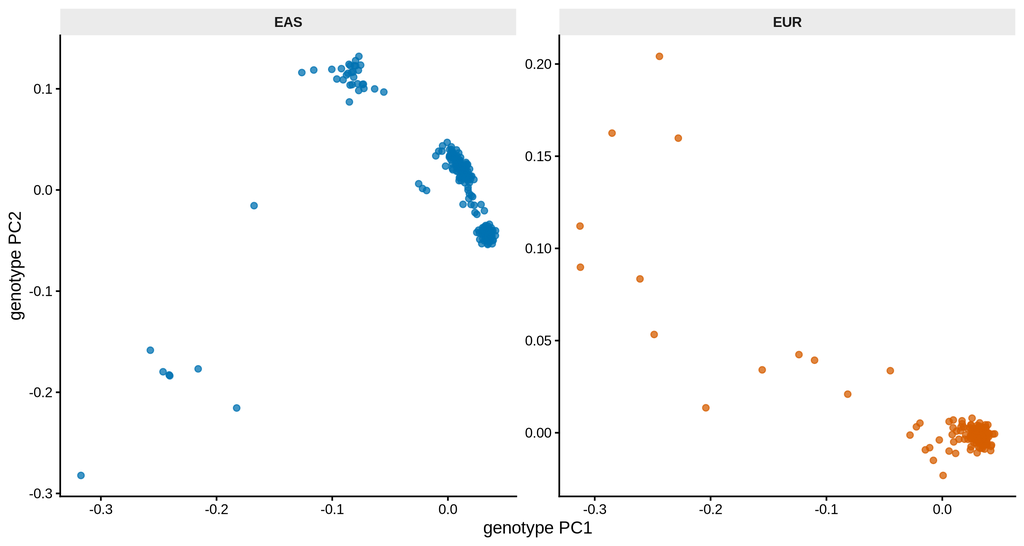

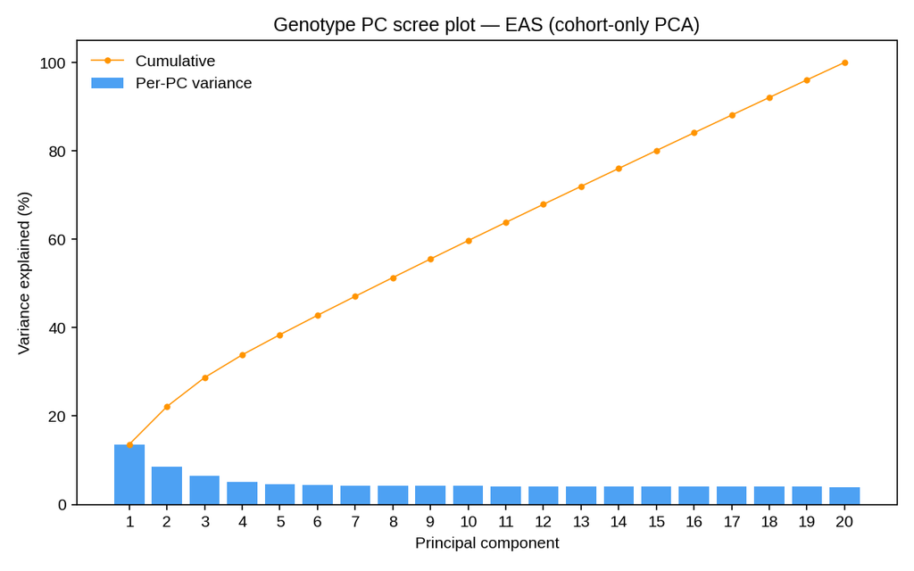

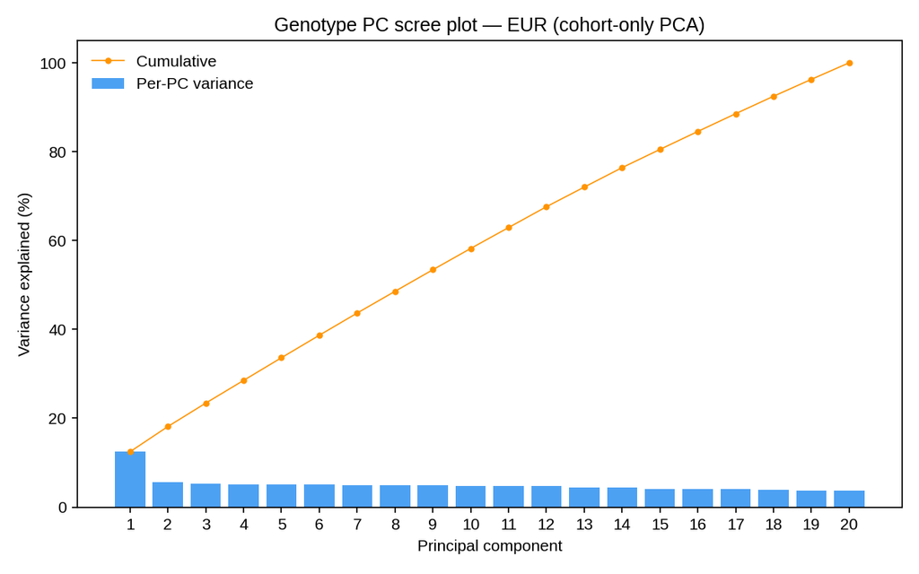

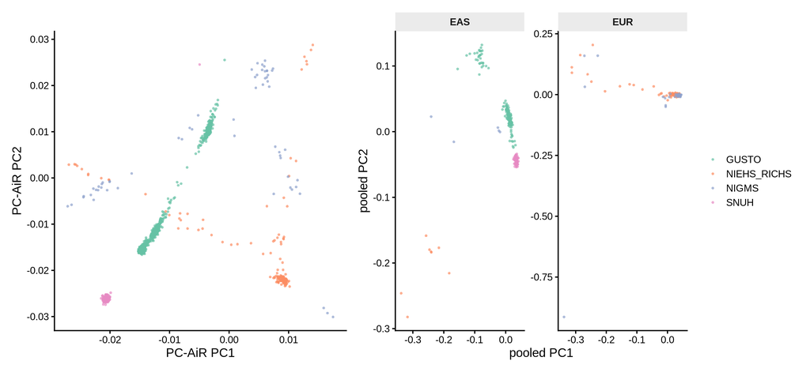

Genotype PCs colored by cohort. On both the shared PC-AiR axes (left) and the pooled within-stratum axes (right), cohorts of the same assigned ancestry occupy distinct but adjacent regions — GUSTO and SNUH resolve within EAS, NIEHS_RICHS and NIGMS within EUR — reflecting fine-scale ancestry composition and platform differences between cohorts. This structure is absorbed by the within-stratum genotype PCs (PC1-5) carried as covariates in every QTL model; the spread of NIEHS_RICHS along pooled EUR PC1 is continuous within-cohort ancestry variation, not a discrete batch.

## 2.4 Covariate QC

Final covariate sets (expression arm shown). Maternal cell-fraction covariate excluded before pruning by analysis decision; HCP count is ancestry × modality-specific from module 25b (per-modality k* in the HCP-optimization section); no covariate cap.

| ancestry | n_covariates | n_samples | genotype_PCs | n_HCP | n_celltypes |
| --- | --- | --- | --- | --- | --- |
| EAS | 58 | 280 | PC1, PC2, PC3, PC4, PC5 | 45 | 6 |
| EUR | 28 | 140 | PC1, PC2, PC3, PC4, PC5 | 15 | 6 |

Covariate pruning log: analysis-decision exclusions, reference cell type, and correlation pruning (|r| > 0.9; HCPs lowest priority — no covariate cap).

| ancestry | covariate | reason | correlated_with | r_value |
| --- | --- | --- | --- | --- |
| EAS | Syncytiotrophoblast | reference_cell_type | NA | NA |
| EAS | ct_Maternal | excluded | NA | NA |
| EUR | Syncytiotrophoblast | reference_cell_type | NA | NA |
| EUR | ct_Maternal | excluded | NA | NA |

PCA outliers excluded (6-SD rule on PC1–PC5, cohort-only PCA).

| ancestry | sample_id | pc | sd_distance |
| --- | --- | --- | --- |
| EAS | S10 | PC5 | 8.26 |
| EUR | SRR13696886 | PC2 | 10.97 |
| EUR | SRR14000138 | PC4 | 8.07 |
| EUR | SRR14000134 | PC5 | 7.38 |
| EUR | SRR13696881 | PC3 | 6.94 |
| EUR | SRR13696876 | PC3 | 6.82 |
| EUR | SRR14000134 | PC4 | 6.72 |

Outlier exclusion on the cohort-only PCs (6-SD rule on PC1–PC5) removed 1 EAS and 5 EUR samples. Pruning dropped 2 covariates in EAS (1 excluded, 1 reference_cell_type) and 2 in EUR (1 excluded, 1 reference_cell_type); both ancestries retained all of PC1–PC5: TRUE, TRUE. Correlated-HCP drops (if any) reduce effective k below the nominal per-modality k* — see the HCP-optimization section.

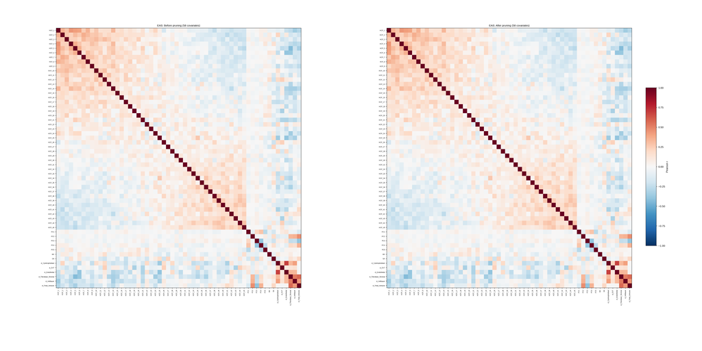

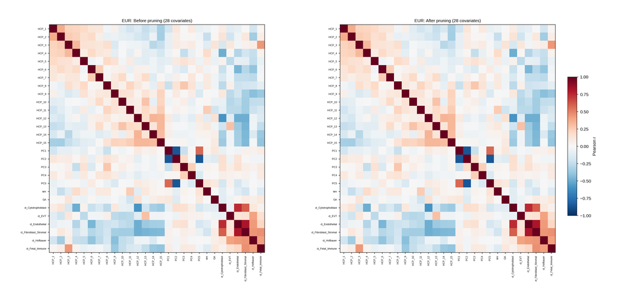

Covariate correlation matrices before/after pruning: no |r| > 0.9 pairs remain in the final sets.

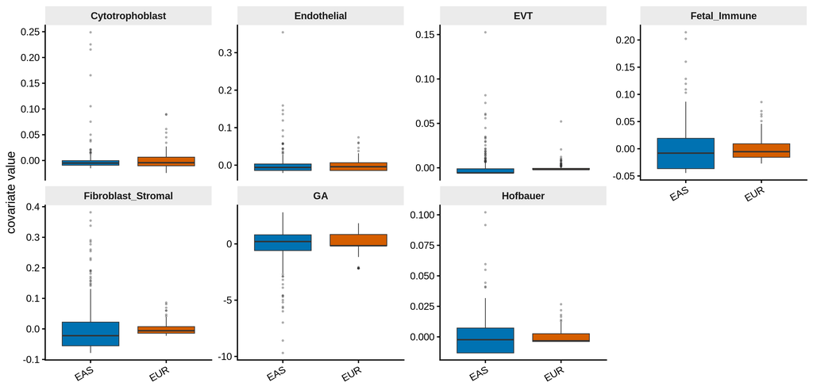

Fixed-covariate distributions per ancestry (final model values; GA is mean-centered, sex is the numeric code, ct_* are deconvolution cell-type proportions).

| ancestry | covariate_id | median | q1 | q3 |
| --- | --- | --- | --- | --- |
| EAS | GA | 0.2081 | -0.5919 | 0.8081 |
| EAS | ct_Cytotrophoblast | -0.0050 | -0.0092 | -0.0003 |
| EAS | ct_EVT | -0.0058 | -0.0058 | -0.0011 |
| EAS | ct_Endothelial | -0.0062 | -0.0141 | 0.0032 |
| EAS | ct_Fetal_Immune | -0.0081 | -0.0366 | 0.0192 |
| EAS | ct_Fibroblast_Stromal | -0.0222 | -0.0554 | 0.0222 |
| EAS | ct_Hofbauer | -0.0023 | -0.0132 | 0.0072 |
| EAS | sex | 0.0000 | 0.0000 | 1.0000 |
| EUR | GA | -0.1627 | -0.1627 | 0.8373 |
| EUR | ct_Cytotrophoblast | -0.0043 | -0.0104 | 0.0065 |
| EUR | ct_EVT | -0.0019 | -0.0019 | -0.0007 |
| EUR | ct_Endothelial | -0.0042 | -0.0142 | 0.0065 |
| EUR | ct_Fetal_Immune | -0.0054 | -0.0157 | 0.0091 |
| EUR | ct_Fibroblast_Stromal | -0.0060 | -0.0142 | 0.0074 |
| EUR | ct_Hofbauer | -0.0033 | -0.0038 | 0.0026 |
| EUR | sex | 0.0000 | 0.0000 | 1.0000 |

## 2.5 Phenotype processing QC

*Before/after view of the two saved processing stages per modality: the pooled unnormalized matrix (input to module 20) and the final QN + INT + ComBat BED used for mapping. Distribution panels show up to 5,000 sampled values per cohort with quartile guides; PCA panels are computed on a 5,000-feature subsample with per-feature z-scoring so before/after geometry is comparable (extraction script 35, section qc).*

Features and samples per modality at each saved processing stage.

| ancestry | modality | stage | n_features | n_samples |
| --- | --- | --- | --- | --- |
| EAS | expression | QN+INT+ComBat | 13045 | 280 |
| EAS | isoforms | pooled unnormalized | 4753 | 283 |
| EAS | isoforms | QN+INT+ComBat | 4672 | 280 |
| EAS | isoform_expression | pooled unnormalized | 12481 | 283 |
| EAS | isoform_expression | QN+INT+ComBat | 12481 | 280 |
| EAS | splicing | pooled unnormalized | 57446 | 282 |
| EAS | splicing | QN+INT+ComBat | 20569 | 279 |
| EAS | intron_retention | pooled unnormalized | 116555 | 283 |
| EAS | intron_retention | QN+INT+ComBat | 3814 | 280 |
| EAS | alt_TSS | pooled unnormalized | 9492 | 283 |
| EAS | alt_TSS | QN+INT+ComBat | 9438 | 280 |
| EAS | alt_polyA | pooled unnormalized | 6879 | 283 |
| EAS | alt_polyA | QN+INT+ComBat | 6859 | 280 |
| EAS | RNA_editing | pooled unnormalized | 3120 | 283 |
| EAS | RNA_editing | QN+INT+ComBat | 3120 | 280 |
| EAS | stability | pooled unnormalized | 2934 | 283 |
| EAS | stability | QN+INT+ComBat | 2934 | 280 |
| EUR | expression | QN+INT+ComBat | 13684 | 140 |
| EUR | isoforms | pooled unnormalized | 12149 | 145 |
| EUR | isoforms | QN+INT+ComBat | 11330 | 140 |
| EUR | isoform_expression | pooled unnormalized | 21802 | 145 |
| EUR | isoform_expression | QN+INT+ComBat | 21801 | 140 |
| EUR | splicing | pooled unnormalized | 50875 | 143 |
| EUR | splicing | QN+INT+ComBat | 32370 | 138 |
| EUR | intron_retention | pooled unnormalized | 91686 | 145 |
| EUR | intron_retention | QN+INT+ComBat | 10717 | 140 |
| EUR | alt_TSS | pooled unnormalized | 21867 | 145 |
| EUR | alt_TSS | QN+INT+ComBat | 21845 | 140 |
| EUR | alt_polyA | pooled unnormalized | 22616 | 145 |
| EUR | alt_polyA | QN+INT+ComBat | 22612 | 140 |
| EUR | RNA_editing | pooled unnormalized | 17951 | 145 |
| EUR | RNA_editing | QN+INT+ComBat | 17951 | 140 |
| EUR | stability | pooled unnormalized | 6925 | 145 |
| EUR | stability | QN+INT+ComBat | 6925 | 140 |

Feature-count changes between stages range from -112,741 to 0 features per ancestry x modality (per-stratum detection filters at normalization); sample counts change by -5 to -3 (genotype intersection and outlier exclusion between the pooled and final BEDs).

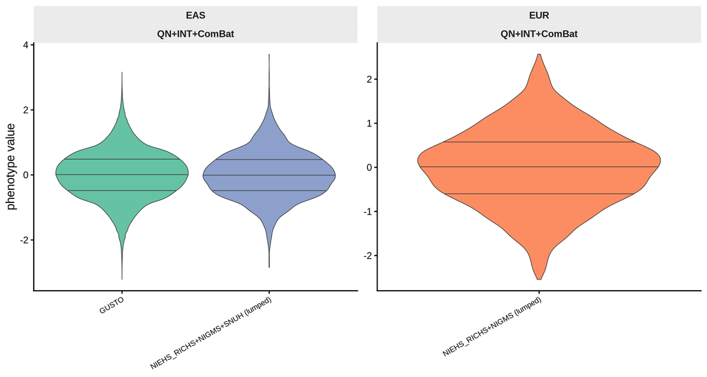

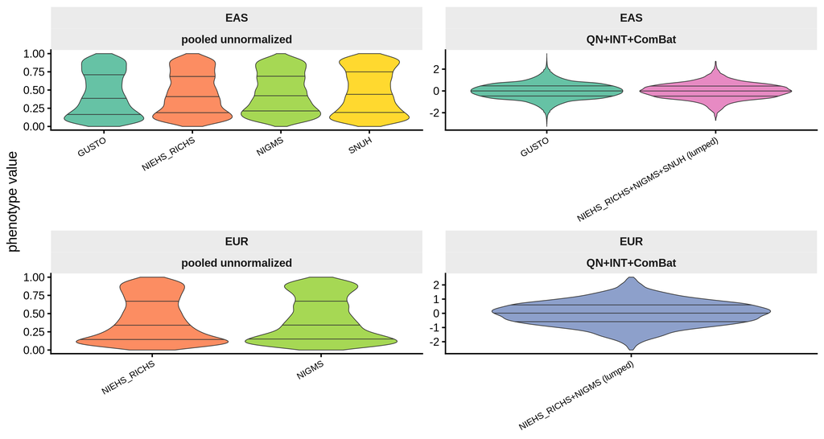

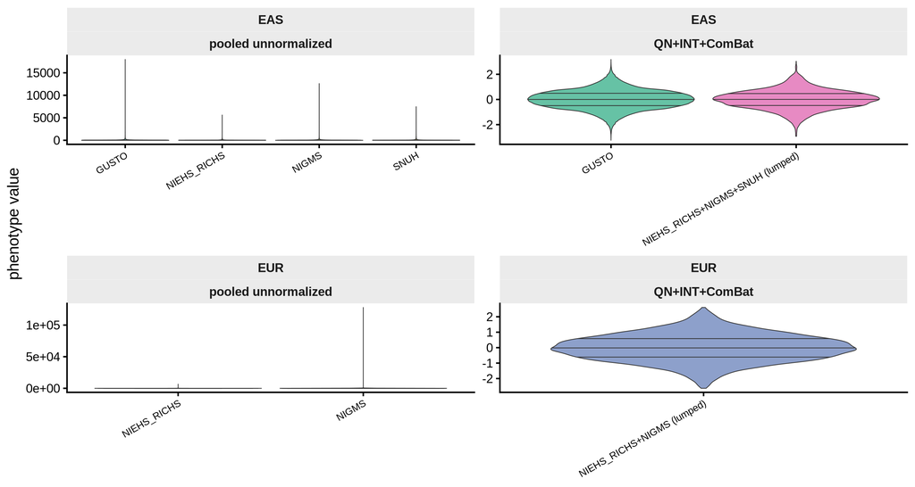

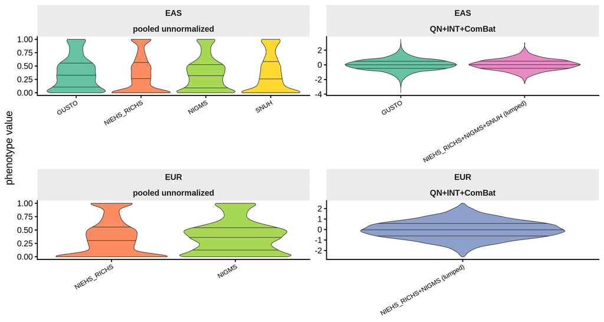

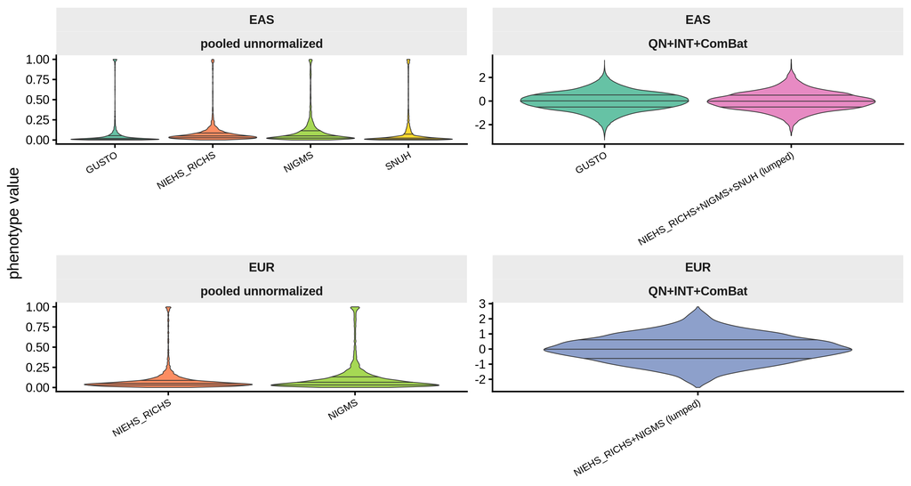

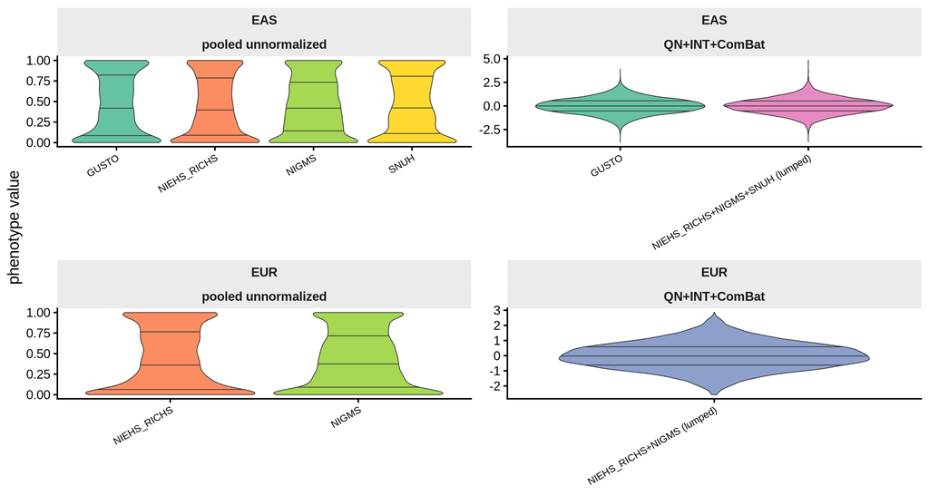

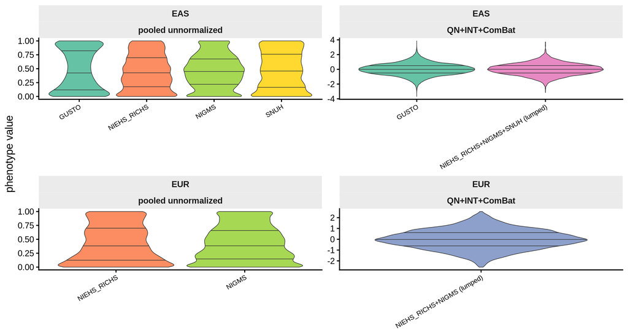

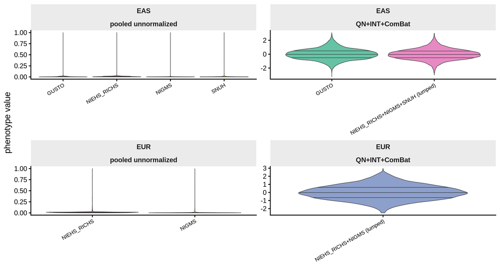

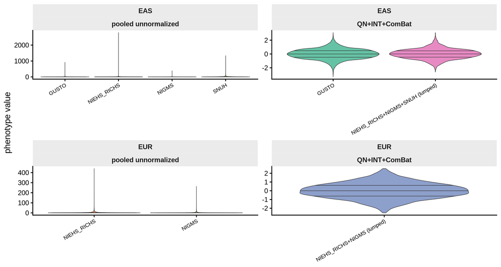

Per-cohort value distributions before (left column) and after (right column) QN + INT + ComBat. Cohort-specific location/scale shifts visible in the pooled unnormalized stage collapse onto a common standard-normal-like distribution after processing; quantile normalization aligns the distributions by construction, and ComBat removes the residual cohort mean shifts. After-stage labels marked ‘(lumped)’ pool cohorts whose array ids carry no cohort namespace — they were lumped at extraction time and cannot be split from the aggregated values (composition shown in the axis label); the PCA panels below resolve the same samples per cohort exactly. Re-running extraction with –geno-ancestry-map labels them per cohort upstream. Expression has no pooled-unnormalized stage (pooling + ComBat is run for the non-expression modalities), so its panel shows the final stage only.

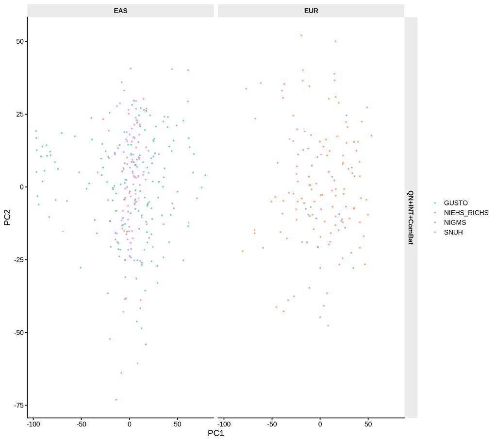

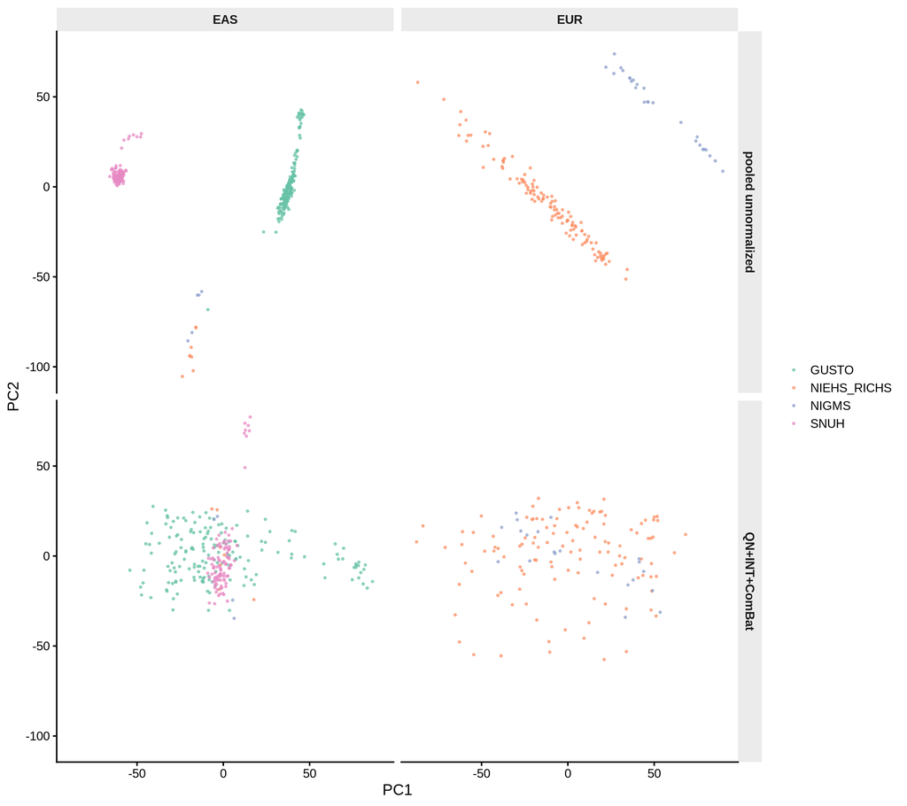

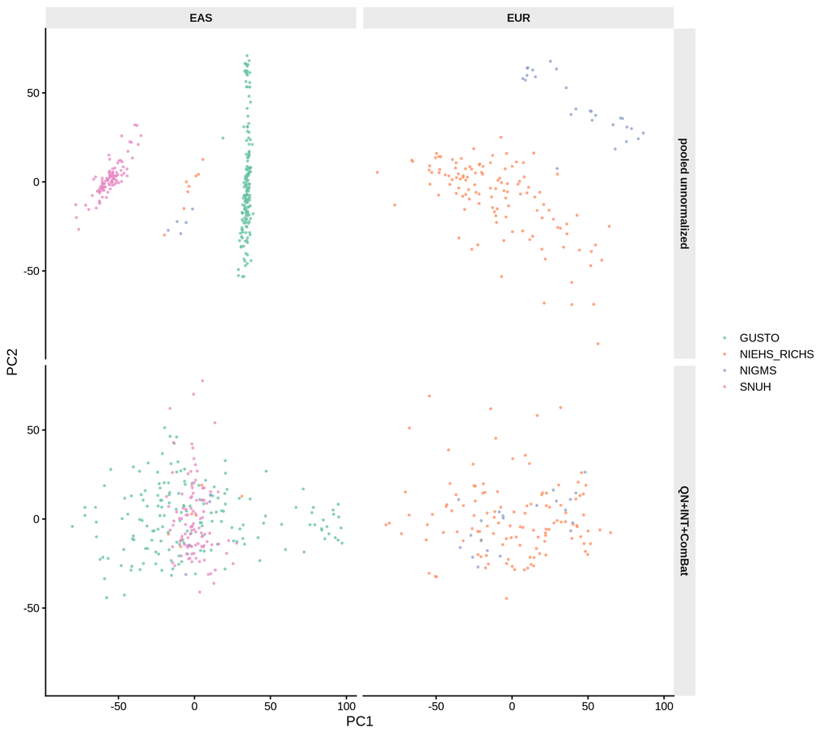

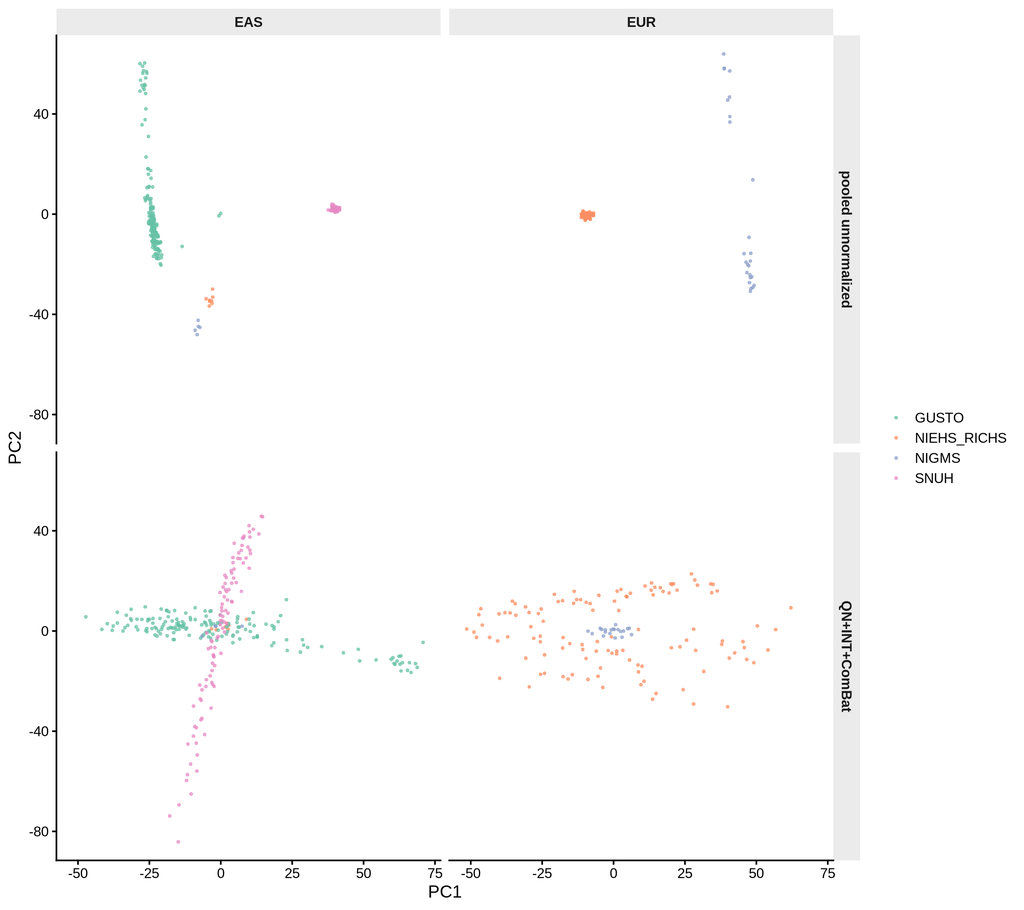

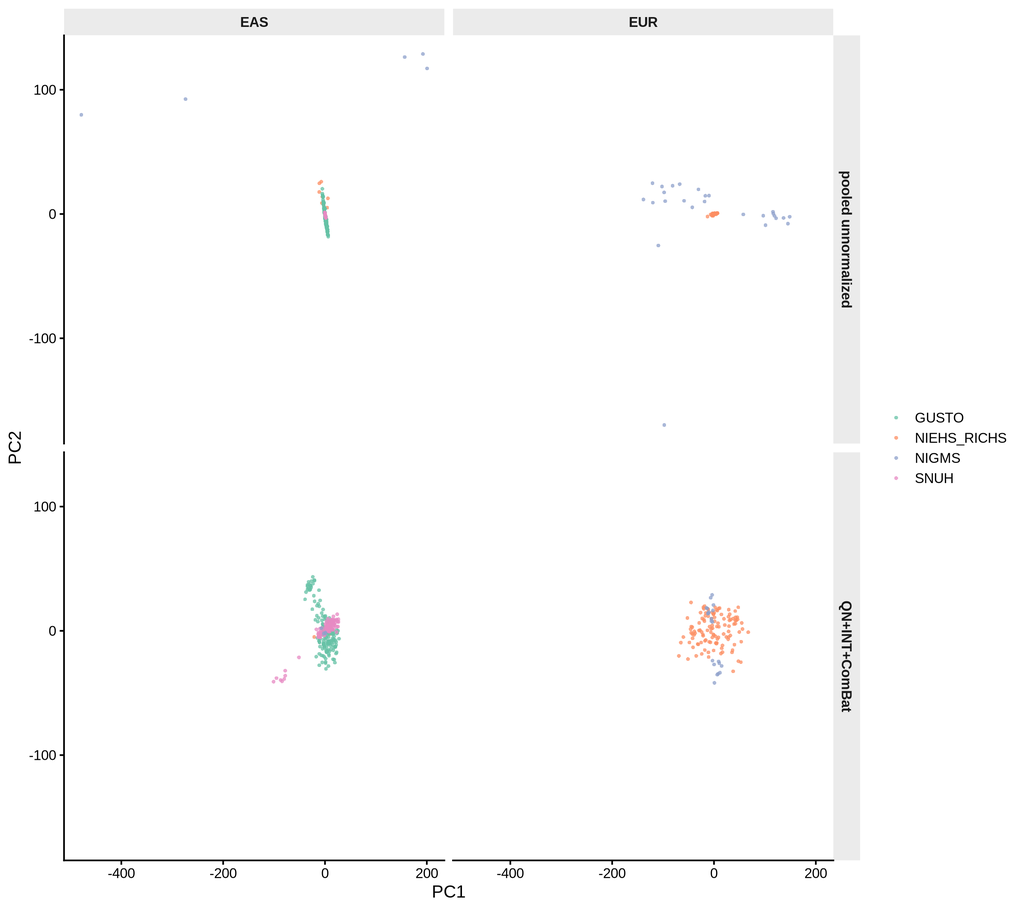

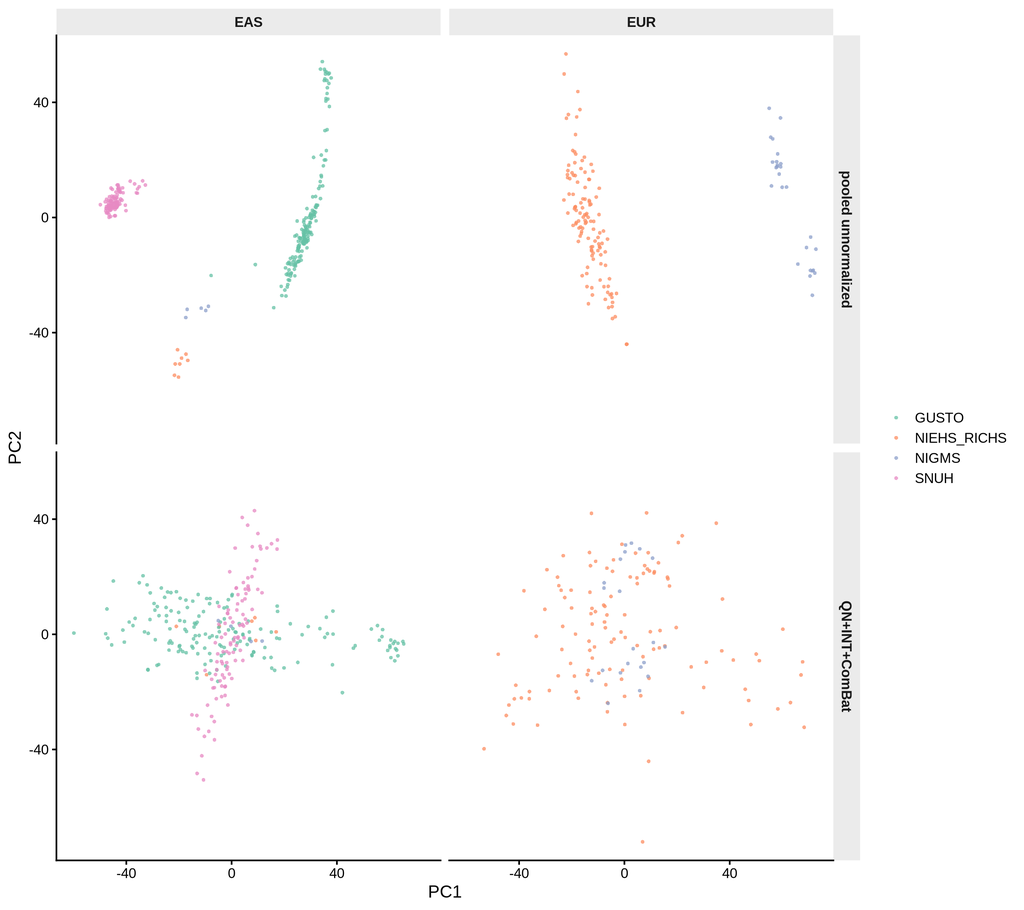

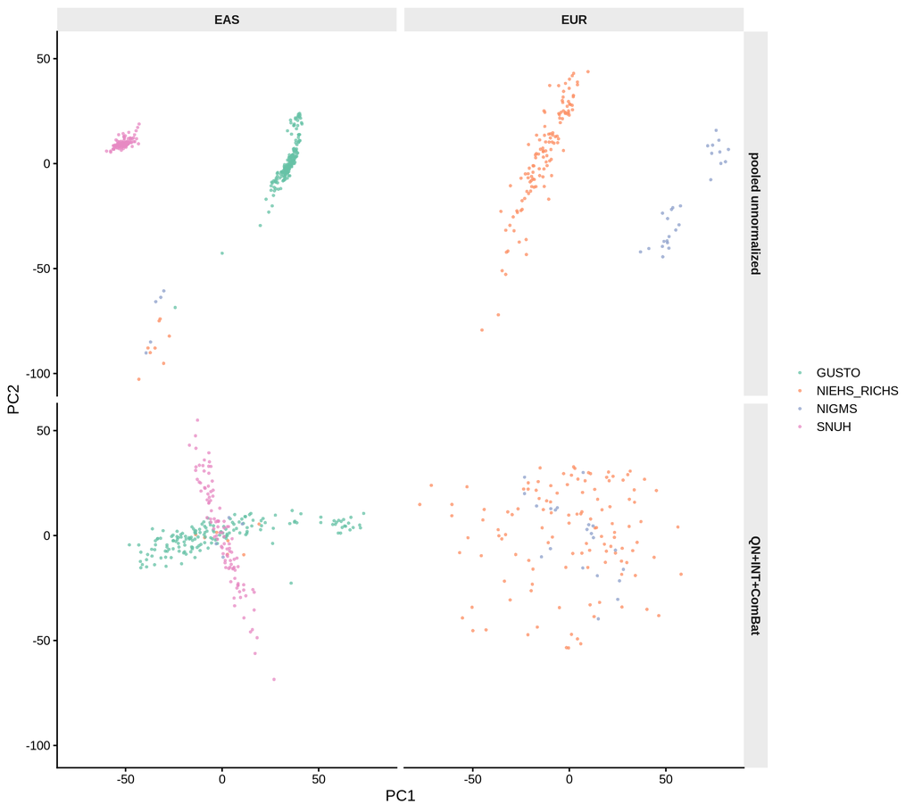

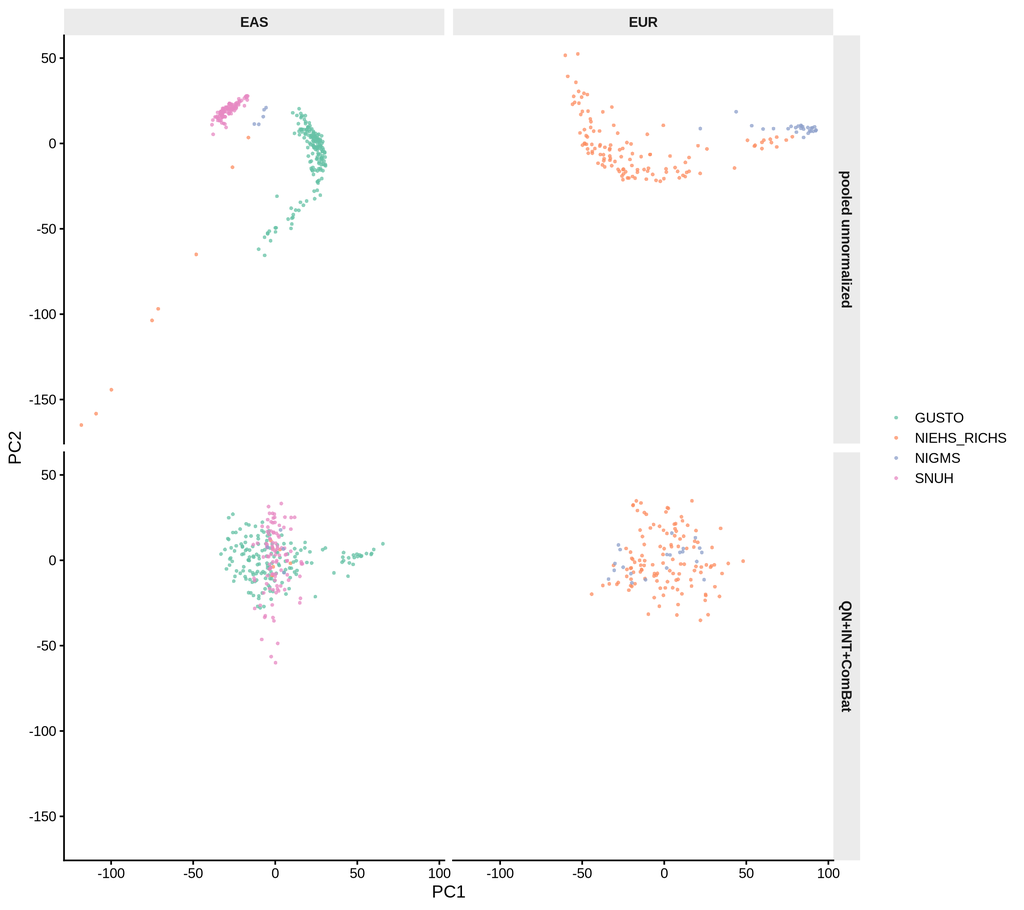

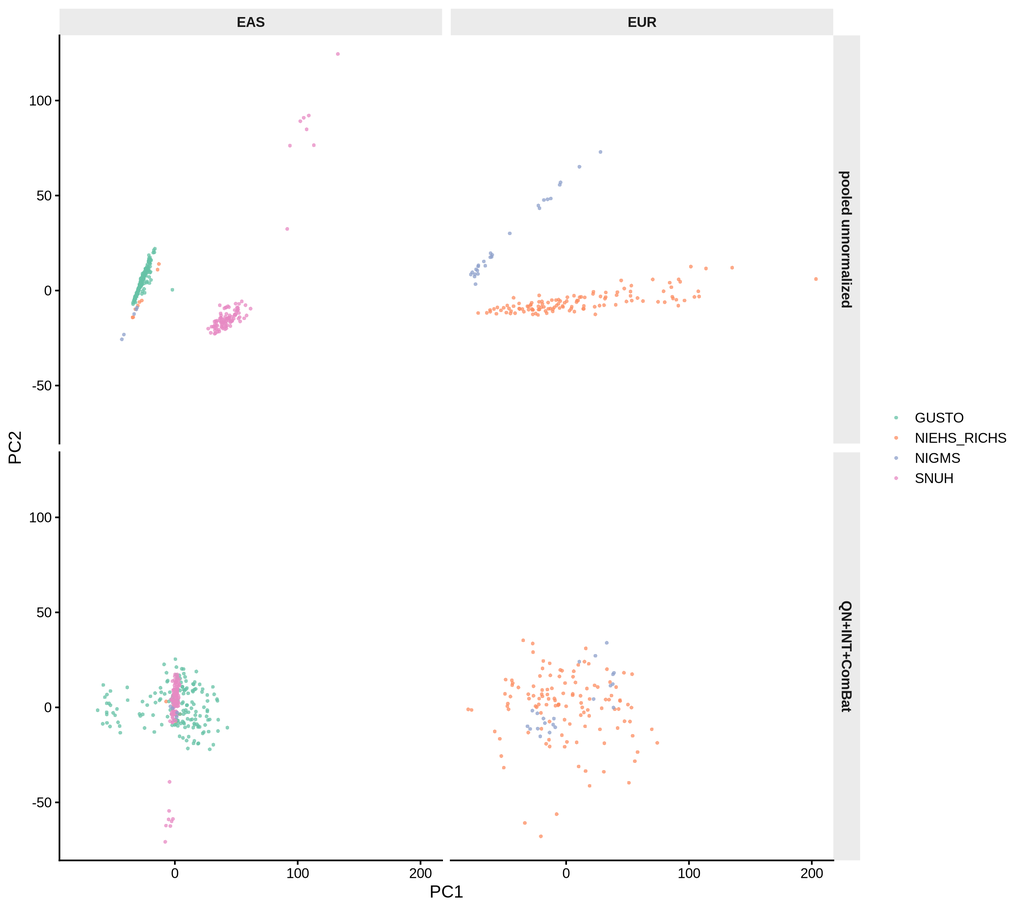

Sample PCA per modality (rows: processing stage; columns: ancestry stratum), colored by cohort. Cohort clustering in the pooled-unnormalized row that disappears in the QN+INT+ComBat row indicates successful batch removal; residual clustering would motivate revisiting the ComBat batch variable.

## 2.6 Sequencing QC

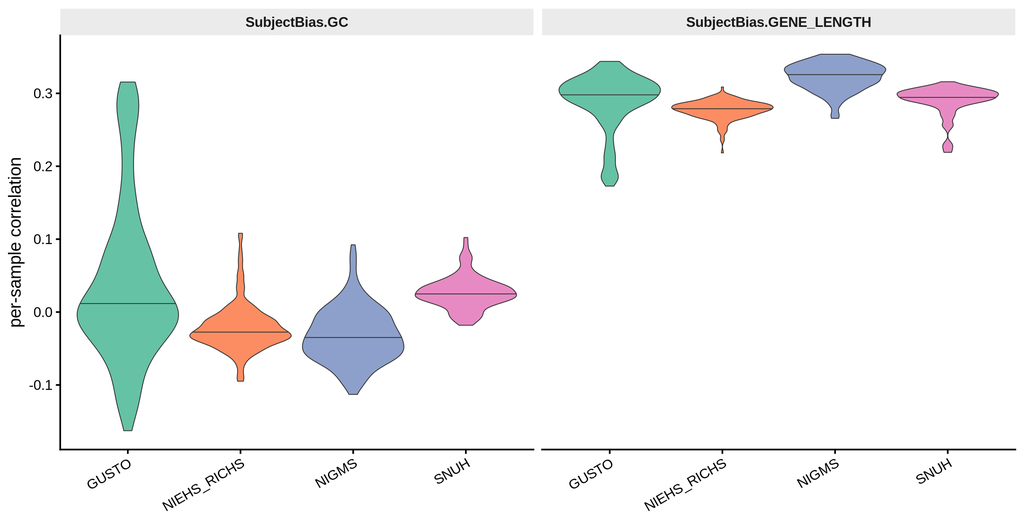

# 3 Pipeline and calibration

## 3.1 Pipeline recap

- **Phenotypes**: 9 RNA modalities (gene expression, isoform usage, isoform expression, splice junction usage, intron retention, alternative TSS, alternative polyA, RNA editing, RNA stability), harmonized to genotyped samples (array_id), with NIGMS technical replicates averaged per individual. The two isoform modalities are both built from QU-corrected Salmon transcript counts (mean count ≥ 10): **isoform usage** is within-gene relative-abundance ratios (transcript TPM / gene-total TPM; PANTRY convention, mean ratio in [0.05, 0.95]) and **isoform expression** is the pre-ratio transcript TPM abundance (DevBrain §3.3 convention). Per ancestry stratum: feature filtering (isoform usage: usage > 0.1 in > 25% of samples; isoform expression: TPM > 0.1 in > 25% of samples, DevBrain §3.3; ratio modalities: detected in ≥ 40%, DevBrain §3.4), batch-median NA imputation, quantile normalization across samples + rank-based inverse-normal transformation per phenotype, then ComBat (batch = cohort) **last** — the DevBrain “ComBat on the normalized data” convention. No log2 pre-transform is applied: rank-based INT is invariant to any monotone transform, so log2/VST would be exact no-ops on the mapped scale.
- **Genotypes**: ancestry-stratified plink2 pgen; variants filtered to **MAF ≥ 0.01 with MAC ≥ 5** (≥ 5 minor alleles) at the genotype intersection — the count floor excludes low-carrier tests, which can produce spurious associations, while MAF 0.01 keeps the variant pool as large as defensible. tensorQTL’s own MAF ≥ 0.01 filter applies on top at mapping time.
- **Genotype PCA**: cohort-only PCA per ancestry on LD-pruned variants (plink2 `--indep-pairwise 200 50 0.2`, then `--pca 20 exact`) — the GTEx convention.
- **Covariates**: per ancestry × modality, first-5 genotype PCs + HCP factors 1–k* (k* selected per ancestry × modality by module 25b, chr1 eGene maximization on each modality’s own HCPs) + sex + gestational age + cell-type fractions (Syncytiotrophoblast as reference). The maternal cell-fraction covariate (`ct_Maternal`) is excluded BEFORE pruning by analysis decision (coded `--exclude-covariates`); the remaining pool is correlation-pruned (iterative max-|r| > 0.9 removal, protecting sex/GA > PCs > cell types > HCPs — correlated HCPs are dropped, so effective k can fall below nominal k*) with **no covariate cap** (details and QC below).
- **Mapping** (tensorQTL, cis window ±1 Mb): (i) **per-modality grouped** — all phenotypes of a gene within a modality tested as one group (permutation-calibrated gene-level p-value; the row label is the *driver phenotype*); (ii) **combined** — all phenotypes of a gene across all modalities as one cross-modality group (PANTRY’s headline design); (iii) **ungrouped** — per-phenotype lead variants for transcript-level resolution, and the discovery layer of record for fine-mapping; (iv) **stepwise** (`cis.map_independent`) for conditionally independent signals, entered at FDR ≤ 5% and run on the grouped, ungrouped, and combined layers alike.
- **Multiple testing**: **Storey q-values** on the permutation-calibrated p-value (pval_beta), computed with the R `qvalue` package (default lambda) — the GTEx convention, and statistically identical to tensorQTL’s own `calculate_qvalues`. (On this cluster the rpy2/conda-R route to `qvalue` hits an unresolvable libstdc++/GLIBCXX conflict, so q-values are computed through a file-based bridge to the singularity R container used elsewhere in the pipeline.)

## 3.2 HCP count optimization (module 25b)

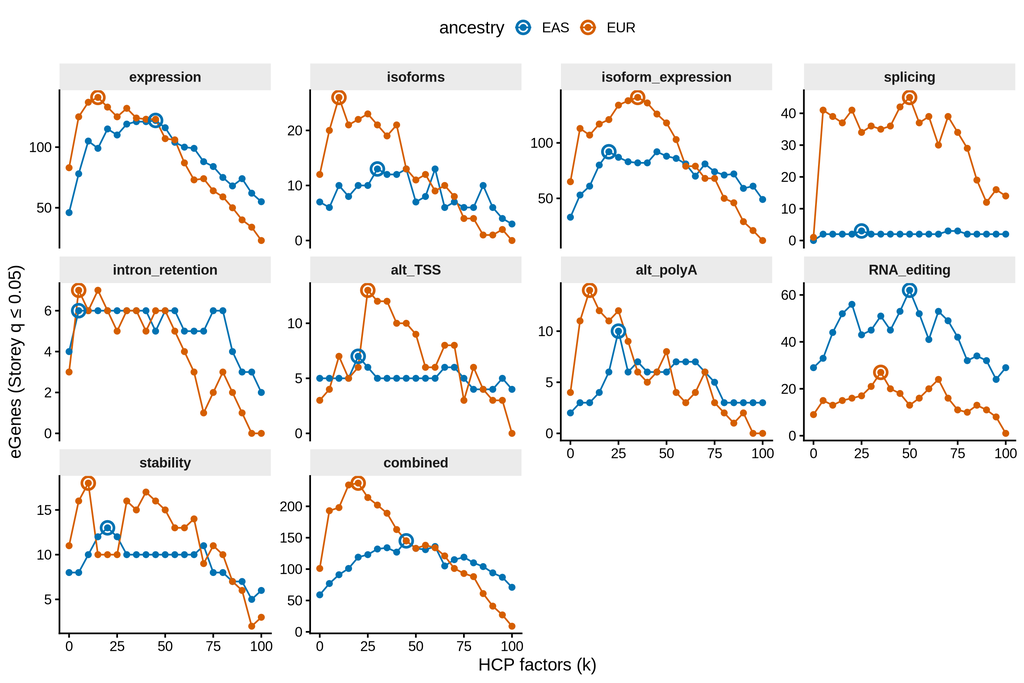

## 3.3 Permutation-calibrated p-value QQ plots

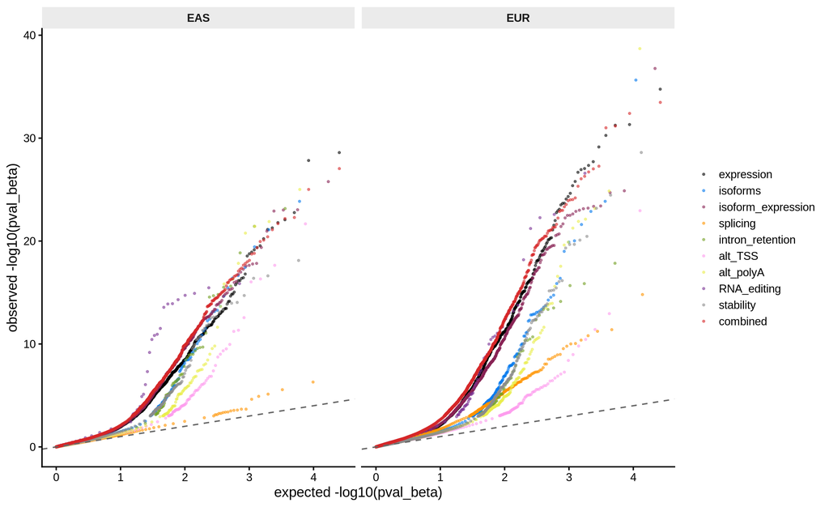